# Predicting the Sole Survivor: Winners vs. Losers

Emma Hill

05/12/2022

```r
# Load any R Packages you may need
library(tidyverse)
library(survivoR)
library(lubridate)
library(tidymodels)
library(ggridges)
library(rpart.plot)
```

# Introduction:

Today we will be examing data from the *survivoR package*, which contains a vast collection of data sets with information across all 41 seasons of the hit US show “Survivor”! This package of data sets can either be downloaded from [GitHub](https://github.com/doehm/survivoR) or simply through CRAN (v0.9.12). These data sets contain information from the details about each season (location, dates, winner, etc.), season details and demographic information about each castaway for every season (gender, DOB, occupation, poc; immunity idols held, total votes received, jury status), and even down to who found each hidden immunity idol! We we use select variables from the “Castaways”, “Castaway details”, “Season summary”, and “Hidden idols” sets and join them together to make one comprehensive Survivor data set.

As an extremely popular, hit reality-competition TV show in the US, Survivor follows a group of contestants–known as “castaways”–who are deliberately marooned on an isolated location and must provide food, water, and shelter for themselves along with competing in challenges for rewards and immunity, all the while avoiding progressive elimination by being voted out by their fellow contestants! In the end, the last person standing is awarded the title of “Sole Survivor” and the grand prize of 1 million dollars. On the surface, winning the “game” of survivor obviously involves a complex interplay of physical strength, cognition and brains, as well as social prowess, however, I am interested in figuring out what factors specifically may contribute to one’s chances of being named Sole Survivor. Thus, using predictive modeling, we can see if and what factors may be predictive of winning and thus shed light on what may be the real true individual strengths when playing the game of Survivor.

# Cleaning the Data:

```r
Idols <- hidden_idols %>%
  select(season, castaway_id, idols_held)
```

The first data set we will use from the survivoR package is the ‘Idols’ data set. From this data set, all we will simply need are the 3 variables of ‘season’ and ‘castaway_id’ to use for joining later on, and the most important varaible, which is ‘idols_held,’ representing how many hidden immunity idols each castaway found individually. We will use ‘idols_held’ later on as a possible predictive feature. By using the select() function, we are able to chop down this hidden_idols data set to only include those three variables, which we then assign to the new object “Idols.”

```r
SeasonYear <- season_summary %>%
  select(season, filming_started) %>%
  mutate(year_filmed = as.numeric(year(filming_started))) %>%
  select(-filming_started)
```

In this data wrangling step, we will use the ‘season_summary” data set for only two of its variables, which we will accomplish by using the select() function. Next, as we really only care about the year in which a season was filmed, we will use the lubridate ’year()’ function to pull *only* the year from all the class date values in the ‘filming_started’ variable, and then follow that up with a select(-) to get rid of the ‘filming_started’ variable.

```r
castaway_info <- castaway_details %>%
  select(-full_name, -date_of_death, -race, -ethnicity, -personality_type)
```

Now using the castaway_details data set, we will once more get rid of the variables we do not need by using a select() function with a ‘-’ in front of the variable names. We will name the resulting data set ‘castaway_info’.

```r
Castaways <- castaways %>%
  left_join(castaway_info, by="castaway_id") %>%
  select(-swapped_tribe, -swapped_tribe_2, -original_tribe, -merged_tribe)
```

We will then use left_join to join our ‘castaway_info’ data set with the larger ‘castaways’ data set. Using left join, the ‘castaways’ data set will be our *main* data frame in which we simply add onto using the information in the “castaway_info” data set. After we joing, we will once more chop down the variables we do not care about using a select(-).

```r
Survivor <- Castaways %>%
  left_join(SeasonYear, by="season") %>%
  mutate(result_status = as.factor(ifelse(result == "Sole Survivor", "Winner", "Loser")))
```

This is one of the most important data cleaning steps, as it involves creating our target variable to be used in our predictive models! After joining our Castaways data set to the SeasonYear data set, we will use the mutate function to create a new variable titled “result_status,” through using a Boolean statement within the ifelse() function. In addition, importantly we included the as.factor() function to ensure that our variable will be of the class factor, which is necessary for it to be able to be used as our target variable in our classification model.

```r
Survivor <- Survivor %>%
  left_join(Idols, by=c("season", "castaway_id")) %>%
  mutate(idols_held = ifelse(is.na(idols_held), 0, idols_held))
```

Similar to the code above, we once more will use a left_join() to add the information in our ‘Idols’ data set onto our main ‘Survivor’ data set, using both the keys of “season” and “castaway_id” to make sure the data is merged correctly, as there are castaways who participated in more than one season. Finally, we will adjust the “idols_held” variable slightly, as the “Idols” data set only held information for castaways who *found* a hidden immunity idol, thus for those who found *0*, there will be an NA as a result of the join in this variable for them. Since the NA then represents a 0, we are able to replace the NAs with 0s in this column usinga an ifelse() function within a mutate().

Cleaning Adjustments for Modelling:

```r
Survivor <- Survivor %>%
    filter(season != "42") %>%
  mutate(sex = ifelse(gender=="Male", "Man", ifelse(gender=="Female", "Woman", NA)))
```

Last but not least, we will also make these quick adjustments to our final data set to enable a seamless creation of our models. First, we will get rid of all the observations for the 42 season of Survivor, as most of the variables for these rows include NAs, which can be inferred as due to the fact that it is a current ongoing season and thus much of the information is not yet know. In addition, there is only one occurrence of the level “Non-binary” in the gender variable, which will result in either the testing or training set getting confused because one of them will not have that level of the variable and thus not know how to handle it. As a solution, we will make a separate ‘sex’ column in which that single observation will be treated as NA to use in our modeling, however the gender column will still exist and that piece of data will as well.

Now we are ready to explore our Survivor data set!!

# Exploring the Data:

### Problem Statement: Our main goal in this project will be to predict the winning status of contestants on Survivor. Thus, we will build a model to predict which castaways win the final title of Sole Survivor and which do not.

## Exploratory Analysis

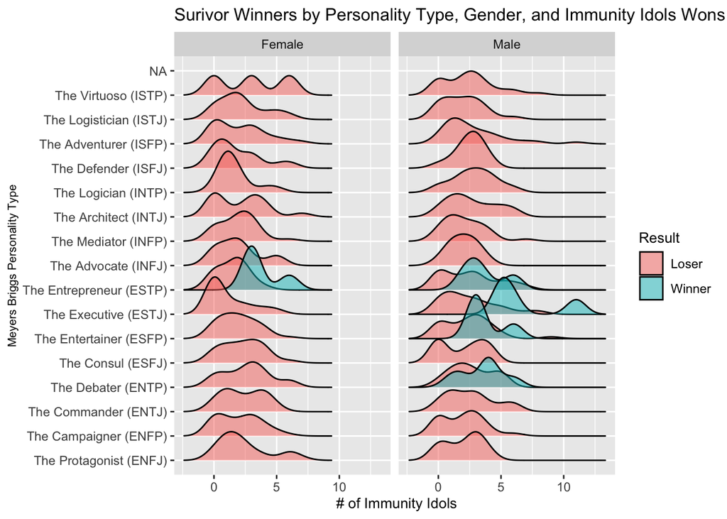

```r
Survivor %>%
  filter(gender != "Non-binary") %>%
ggplot(aes(y=personality_type, x=immunity_idols_won, fill= result_status)) +
  geom_density_ridges(alpha = .5) +
  scale_y_discrete(labels = c( 'The Protagonist (ENFJ)','The Campaigner (ENFP)','The Commander (ENTJ)','The Debater (ENTP)', 'The Consul (ESFJ)', 'The Entertainer (ESFP)','The Executive (ESTJ)','The Entrepreneur (ESTP)', 'The Advocate (INFJ)', 'The Mediator (INFP)','The Architect (INTJ)','The Logician (INTP)','The Defender (ISFJ)','The Adventurer (ISFP)','The Logistician (ISTJ)','The Virtuoso (ISTP)','NA')) +
  facet_wrap(~gender) +
  labs( y = "Meyers Briggs Personality Type", title = "Surivor Winners by Personality Type, Gender, and Immunity Idols Wons", fill = "Result", x = " # of Immunity Idols") +
  theme(axis.title.y = element_text(size = 8),
        title = element_text(size = 10))
```

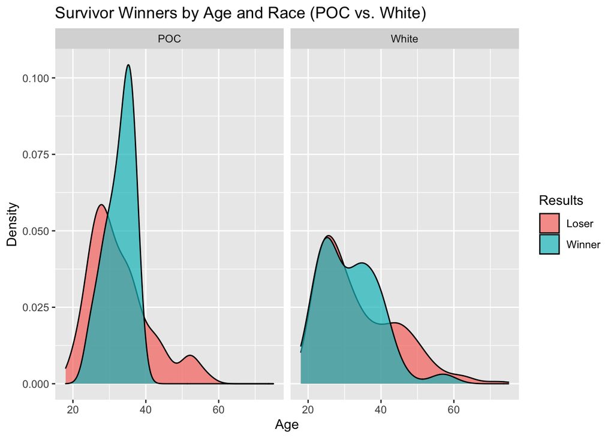

```r
ggplot(Survivor, aes(x=age, fill=result_status)) +
  geom_density(alpha = 0.7) +
  facet_wrap(~poc) +
  labs(x = "Age", fill = "Results", title = "Survivor Winners by Age and Race (POC vs. White)", y = "Density")
```

Now that we have looked at some possible important factors in predicting winning status, lets finnally build our model!

# Building our Model

## Training and Testing Samples:

First, we will divide our Survivor data (n=804) into a training set (training) and testing set (testing). A random sample of 70% of all observations (representative of every survivor castaway participant that has been on the show each season) will be drawn from the overall Survivor data frame for the training set, with the remaining 30% used for the testing set. Data division resulted in n=562 observations to use to train the prediction model (training set), along with n=242 observations to evaluate the predictive model (testing set). We will use set.seed(20) for replication purposes.

```r
set.seed(20)
data_split = initial_split(Survivor, prop = 0.7)

data_train = training(data_split)
data_test = testing(data_split)

list(data_train, data_test) %>%
  map_int(nrow)
```

```
## [1] 562 242
```

## Fit the Model:

Next we will fit our training data using a classification decision tree model, since we are predicting a categorical target! In the fit() function, we define our target as ‘result_status’ and our all of our features (possible predictor variables) after the tilde as ‘age + personality_type + immunity_idols_won + idols_held + sex + poc’. The rpart.plot() is a then a great way to see the visulization of the resulting classification decision tree in which our training set was fitted to (result being our fitted model).

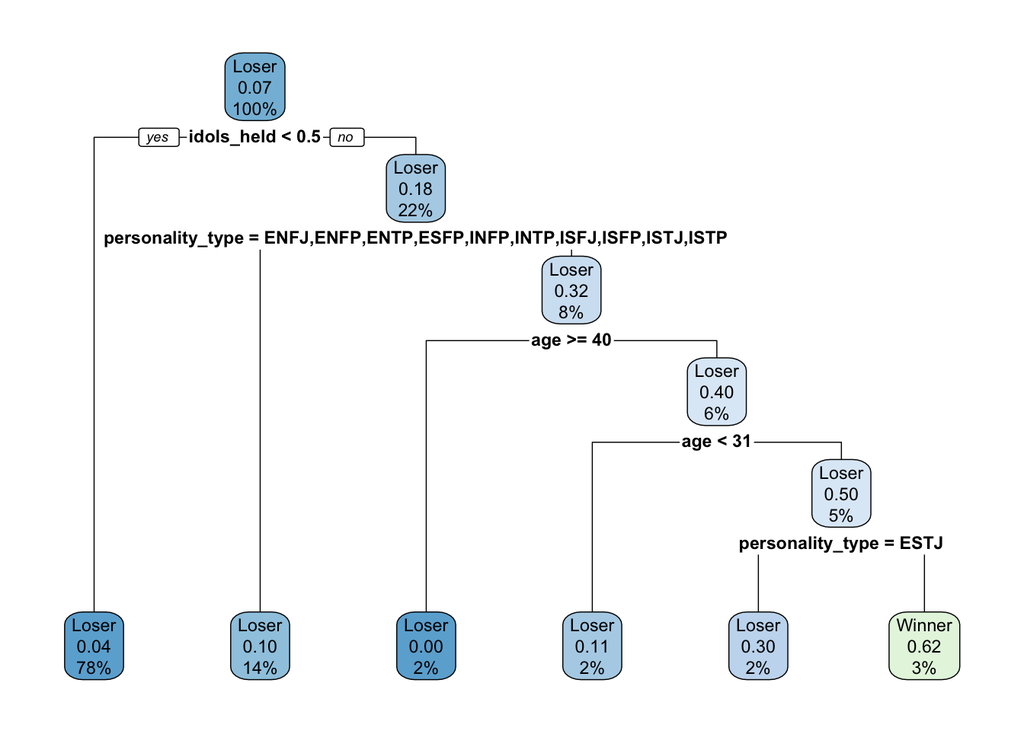

```r
#train the model
data_fit = decision_tree() %>%
  set_mode(mode = "classification") %>%
  fit(result_status ~ age + personality_type + immunity_idols_won + idols_held + sex + poc, data = data_train)

rpart.plot(data_fit$fit, roundint = FALSE)
```

## Generate Predictions:

Next, we will generate predictions using the predict() function on our testing set using our fitted model, with of course defining the type as “class” (classification).

```r
data_pred = data_fit %>%
  predict(new_data = data_test, type = "class")
```

## Testing Predictions:

Finally, we will use the *observed values* in our target variable (result_status) within our testing data to compare to the *predicted values* to evaluate our model.

### Confusion Matrix

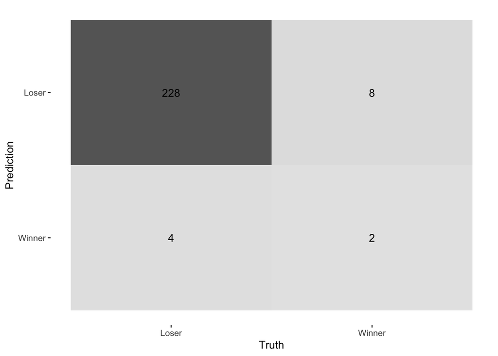

```r
data_test %>%
  mutate(winner_pred = data_pred$.pred_class) %>%
  conf_mat(truth = result_status, estimate = winner_pred) %>%
  autoplot(type = "heatmap")
```

First, we will create a confusion matrix of our model. Right away, we can see that our model is much more accurate at predicting Loser status correctly (228), than it is at predicting Winner status correctly (only 2). To summarize, if conceptualizing Loser as ‘Positive’ and Winner as ‘Negatives’ we can see that our model resulted in: - 228 true positives (for Loser status) - 2 true negatives (for Winner status) - 4 false negatives (predicted winner instead of loser incorrectly) - 8 false positives (predicted loser instead of winner incorrectly) Even just from this single testing metric, we can already begin to see that our model is overfit to predict Loser status and thus, not accurate at predicting Winner status. Lets examine this in more detail.

### Acurracy Test

```r
data_test %>%
  mutate(winner_pred = data_pred$.pred_class) %>%
  accuracy(truth = result_status, estimate = winner_pred)
```

```
## # A tibble: 1 × 3
##   .metric  .estimator .estimate
##   <chr>    <chr>          <dbl>
## 1 accuracy binary         0.950
```

Using the accuracy() function here to evaluate our model is quite misleading, as it instead reflects the fact that our model is overfit to predict Loser status, meaning because Loser status occurs so much more frequently than Winner status, our model may just be blindly predicting Loser status for all of the testing set observations.

### Sensitivity

```r
data_test %>%
  mutate(winner_pred = data_pred$.pred_class) %>%
  sens(truth = result_status, estimate = winner_pred)
```

```
## # A tibble: 1 × 3
##   .metric .estimator .estimate
##   <chr>   <chr>          <dbl>
## 1 sens    binary         0.983
```

### Specificity

```r
data_test %>%
  mutate(winner_pred = data_pred$.pred_class) %>%
  spec(truth = result_status, estimate = winner_pred)
```

```
## # A tibble: 1 × 3
##   .metric .estimator .estimate
##   <chr>   <chr>          <dbl>
## 1 spec    binary           0.2
```

### ROC curve

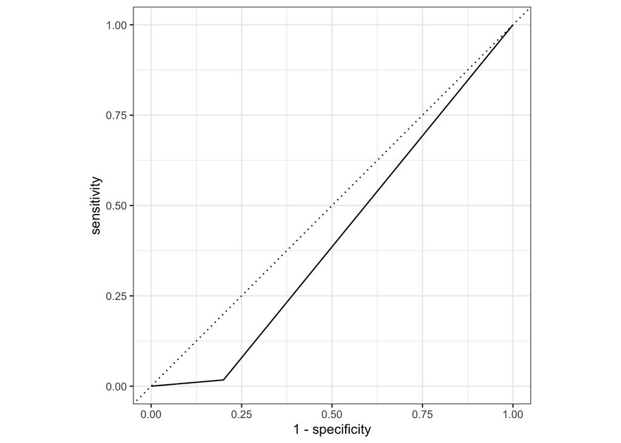

```r
data_test %>%
  mutate(winner_pred = as.numeric(data_pred$.pred_class)) %>%
  roc_curve(truth = result_status, estimate = winner_pred) %>%
  autoplot()
```

Looking at the sensitivity score, specificity score, and ROC curve for our model shows a similar trend. Sensitivity is the proportion of true positives. As we already discussed, our model is really good at predicting Loser status, which is by far the majority level in our data set compared to Winner status, with 755 Losers and 49 Winners in our total data set. As a result, even though our model is bad at predicting Winner status, because it is such an extreme minority proportion of the data overall, it does not impact our overall high sensitivity score. Thus, our sensitivity score of 98% only represents the accuracy (and resulting over fitting) of our model for Loser status.

On the other hand, our specificity score is more representative of our model being over fit to the severe imbalance of Losers vs Winners, as it reflects the proportion of true negatives which are the amount of times our model accurately predicted Winner status. As the .2 or 20% reflects, our model is really bad at predicting Winner status.

Finally, finding and plotting the ROC curve also reflects a similar picture, as this method illustrate the predictive abilities of our model through the amount of area represented under the curve. Given that our curve falls underneath the classifer line, we can clearly see that the area is relatively very low and thus our model’s predictive abilties are not very strong.

# Conclusion

As the evaluation of our model shows, the classification decision tree that we created to predict Winner or Loser status for Survivor is not a very good model. As our metrics have proven, due to the extreme imbalance in the proportion of the two levels within our target variable, with Winners only making up 6% of the data (49/755), the model has been trained to blindly over predict Loser status, while simultaneously not knowing how to predict Winner status.

This flaw in our model stems mainly from the severe limitations of our data set being so strongly imbalanced. However, due to the low sample size of our overall data set, with n=804, we are also limited in the steps we can take to adjust for the flaws in our model. Most importantly, we are unable to down sample and then refit and retrain our model as our sample size is simply way too small overall, as well as the proportion of the variable level which we would need to down sample is so minute, that this is not an option. One method one could take however is over sampling, which would involve duplicating samples from the minority class of Winner status within our data set to increase the proportion of Winners overall. However a big draw back to this method would also be that our model would even further be over fit to only be able to predict winner status specifically for the 50 observations included in this data set and would have very little ability to generalize to any other data.

Overall, through this process we have learned a few things. For one, as it may be obvious, the pool of Survivor contestants is quite limited, even after 41 seasons, providing us with a data set and sample of only 804 observations, which made it hard to create an accurate predictive model, compounded by how less likely one is to win Survivor than one is to lose Survivor. Even further, our data set has the possibility of strong selection bias, as previously alluded to. There is only a select few amount of people chosen to be contestants on Survivor every season. These contestants are selected from what can be assumed to be a huge pool of applicants, and thus, there is likely to be eligibility requirements and thus significant sampling bias. In addition, we also have to consider the fact that there may be only certain types of people may even simply apply to be on Survivor, much less get selected, thus creating the strong possibility of volunteer bias in our sample. As a result, overall, through this process, it has become extremely clear that our initial goal of predicting the winning status of people on Survivor is a difficult one to model with this data, and may simply be difficult to accuratly accomplish overall given the low generalizability of any Survivor samples to the general public.